# R Notebook

Mohammad Amr Khan

*Practice Questions from PAISAS Chapter 4*

## Packages

```r
library(tidyverse)
```

## Orange Juice

The data set is available online and looks to be a space delimited txt file

```r
oj_url <- "https://www.utsc.utoronto.ca/~butler/c32/ojuice.txt"
oj_data <- read_delim(oj_url, " ")
```

The column specification shows that there are three columns, with the headings run, sweetness and pectin.

We can we the data, by called the data frame

```r
oj_data
```

| run | sweetness | pectin |
| --- | --- | --- |
| 1 | 5.2 | 220 |
| 2 | 5.5 | 227 |
| 3 | 6.0 | 259 |
| 4 | 5.9 | 210 |
| 5 | 5.8 | 224 |
| 6 | 6.0 | 215 |
| 7 | 5.8 | 231 |
| 8 | 5.6 | 268 |
| 9 | 5.6 | 239 |
| 10 | 5.9 | 212 |

[output cut: 14 more lines]

We see there is data for 24 runs

As we are interested between the relationship between sweetness and pectin, both of which are quantitative variables, we will use a scatterpolt

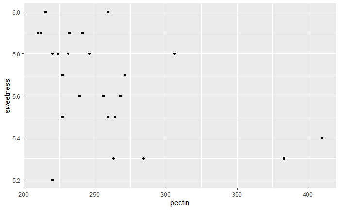

```r
ggplot(oj_data, aes(x = pectin, y = sweetness)) + geom_point()
```

There does appear to be a negative relationship between pectin and sweetness. As the pectin levels increase, the sweetness value decreases.

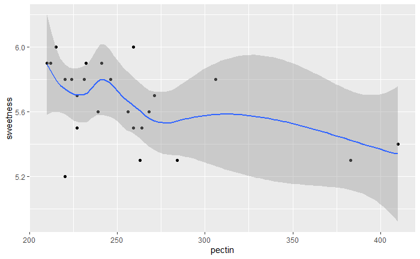

```r
ggplot(oj_data, aes(x = pectin, y = sweetness)) + geom_point() + geom_smooth()
```

The loess curve does show a negative relative but not too convincing

## Making Soap

Data available on the website

```r
soap_url <- "https://www.utsc.utoronto.ca/~butler/c32/soap.txt"
soap_data <- read_delim(soap_url, " ")
```

The data has been ingested and shows that there are 4 columns

```r
soap_data
```

| case | scrap | speed | line |
| --- | --- | --- | --- |
| 1 | 218 | 100 | a |
| 2 | 248 | 125 | a |
| 3 | 360 | 220 | a |
| 4 | 351 | 205 | a |
| 5 | 470 | 300 | a |
| 6 | 394 | 255 | a |
| 7 | 332 | 225 | a |
| 8 | 321 | 175 | a |
| 9 | 410 | 270 | a |
| 10 | 260 | 170 | a |

[output cut: 17 more lines]

we can see 27 runs

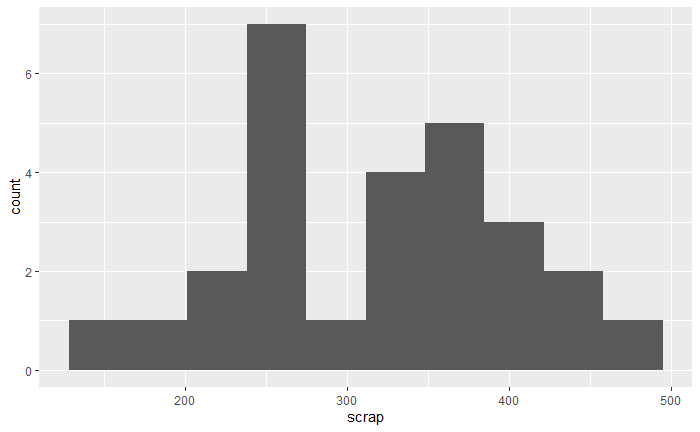

we see two peaks one around 260 and another at 360. This does not show normal distribution but rather bimodal.

We want to compare the production lines and their scrap values

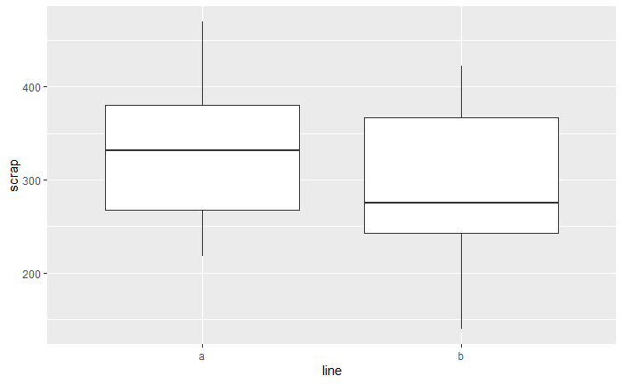

```r
ggplot(soap_data, aes(x = line, y = scrap)) + geom_boxplot()
```

The median on line A is higher than that of line b. There is overlap between the boxplots so there is not a large difference between the lines.

To see if there is a relationship between the speed and scrap produced we can used a scatterplot

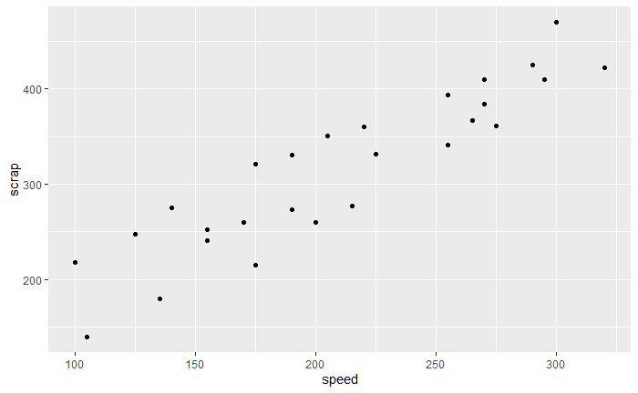

```r
ggplot(soap_data, aes(x = speed, y = scrap)) + geom_point()
```

This does show a positive correlation, means that as speed increases so does the amount of scrap produced.

Let’s see if there is a difference between the lines

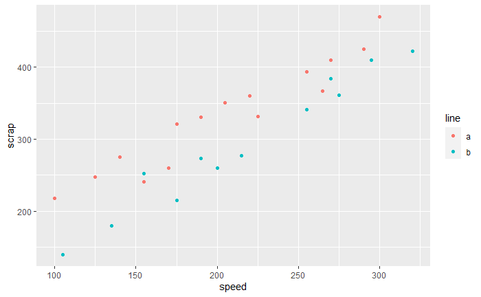

```r
ggplot(soap_data, aes(x = speed, y = scrap, colour = line)) + geom_point()
```

Apart from two data points this graph shows that line a produces more scrap than line b at similar speeds

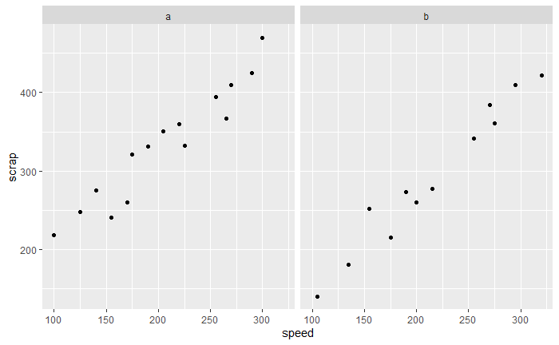

```r
ggplot(soap_data, aes(x = speed, y = scrap)) + geom_point() + facet_wrap(~line)
```

## Handling Shipments

A company called Global Electronics from time to time imports shipments of a certain large part used as a component in several of its products. The size of the shipment varies each time. Each shipment is sent to one of two warehouses (labelled A and B) for handling.

The data is in a csv file

```r
shipments_url <- "http://www.utsc.utoronto.ca/~butler/c32/global.csv"
shipment_data <- read_csv(shipments_url)
```

The data has been read and R tells us that this data set has three columns - warehouse, size and cost which based of the description makes sense

```r
shipment_data
```

| warehouse | size | cost |
| --- | --- | --- |
| A | 225 | 11.95 |
| B | 350 | 14.13 |
| A | 150 | 8.93 |
| A | 200 | 10.98 |
| A | 175 | 10.03 |
| A | 180 | 10.13 |
| B | 325 | 13.75 |
| B | 290 | 13.30 |
| B | 400 | 15.00 |
| A | 125 | 7.97 |

we see there are 10 rows of data and 3 columns.

We can use a scatterplot to see if there is a relationship between handling costs and shipment size

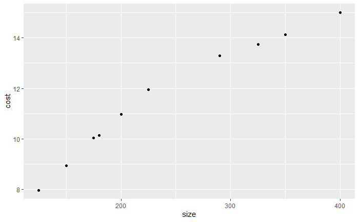

```r
ggplot(shipment_data, aes(x = size, y = cost)) + geom_point()
```

The scatter plot appears to show a almost linear relationship between the handling costs and shipment size. As the size increases so does the cost

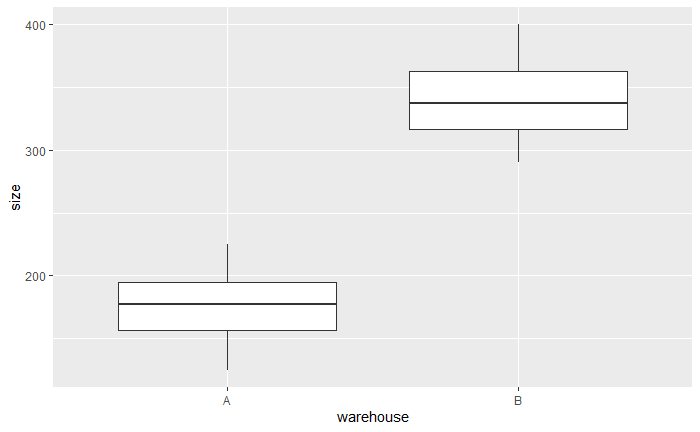

```r
ggplot(shipment_data, aes(x = warehouse, y = size)) + geom_boxplot()
```

The median of the shipment sizes for warehouse b are must larger than those for warehouse A. The boxplot shows us that the larger shipments are sent to warehouse b.

To see the relationship between size and cost while including which warehouse we can use a grouped scatter plot

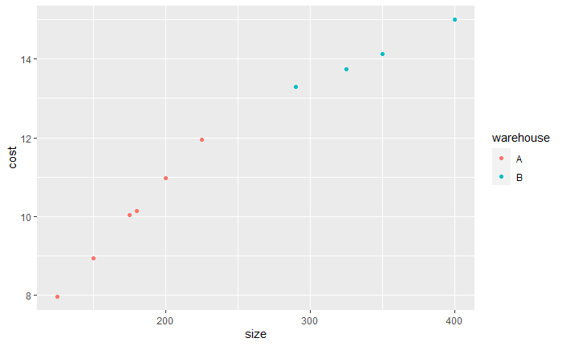

```r
ggplot(shipment_data, aes(x = size, y = cost, colour = warehouse)) +
  geom_point()
```

The slope for warehouse a is steeper than that for warehouse B.